# Reproducing Section 5: BARTSIMP simulation experiments

BARTSIMP reproduction materials

This vignette reproduces the simulation study in Section 5 of

> Jiang, A. Z., & Wakefield, J. (2025). *BARTSIMP: Flexible spatial covariate modeling and prediction using Bayesian Additive Regression Trees.* Spatial and Spatio-temporal Epidemiology, **55**, 100757. https://doi.org/10.1016/j.sste.2025.100757

It compares **BARTSIMP** against three competitors on a gridded spatial surface and reports the paper’s four performance criteria. Everything here runs on self-contained synthetic data — no external downloads are required.

# 1 What Section 5 does

The design (paper Section 5.1):

- A 50 x 50 grid over $[0,1]^2$ ($|G| = 2500$ cells).
- Two covariates $x_1, x_2 \sim \mathrm{Unif}(0,1)$ per cell.
- A baseline spatial field $z^\* \sim \mathrm{GRF}$ with a Matérn ($\kappa = 2.5$, $\nu = 1$, $\sigma_m^2 = 0.5$) covariance.
- A covariate surface $f_0(x)$: `tree`, `linear`, or `smooth`.
- The **true field** blends the two:
  $$f(x_g) = (1 - \omega)\, z^\*_g + \omega\,
  f_0(x_g), \qquad
  \omega \in \{1, 0.8, 0.5, 0.2, 0\}.$$
  $\omega$ is the *covariate-signal share*: $\omega = 1$ is a pure covariate surface, $\omega = 0$ is a pure spatial field.
- 250 clusters are sampled (one location per chosen cell); each cluster has $n_j \sim \mathrm{Unif}\{5,\dots,10\}$ noisy observations $y_{ij} = f(\text{cell}_j) + N(0, \sigma_e^2 = 1)$.

Every method is trained on the 250-cluster observations and asked to predict the noise-free field $f(x_g)$ at all 2500 grid cells.

The methods (paper Section 5.1):

| Method | Covariate model | Spatial field | Fitted with |
| --- | --- | --- | --- |
| BARTSIMP | BART ensemble | Matérn SPDE | `BARTSIMP` |
| BART | BART ensemble | *none* | `dbarts` |
| SPDE | linear | Matérn SPDE | `INLA` |
| SPDE0 | intercept only | Matérn SPDE | `INLA` |

The performance criteria (paper Section 5.2), all averaged over $G$:

- **RMSE** — point-prediction accuracy.
- **AIL** — average $(1-\alpha)$ interval length.
- **ACR** — average coverage rate (nominal $1-\alpha = 0.95$).
- **AIS** — average interval score (Gneiting & Raftery, 2007); lower is better.

# 2 Setup

```r
library(BARTSIMP)
if (requireNamespace("INLA", quietly = TRUE))
  try(INLA::inla.setOption(fmesher.evolution.warn = FALSE), silent = TRUE)

# The reproduction building blocks live in reproduction/R/. Sourcing the runner
# pulls in the DGP, metrics, competitors, and the BARTSIMP fitter. `.repro_R`
# tells the runner where those files are (knitr sets the working directory to
# this .Rmd's folder, so "R" resolves to reproduction/R).
.repro_R <- if (dir.exists("R")) normalizePath("R") else normalizePath("reproduction/R")
source(file.path(.repro_R, "run_scenario.R"))
```

`dbarts` and `INLA` are needed for the competitors; `INLA` is also used inside BARTSIMP. See `reproduction/README.md` for installation notes.

# 3 One scenario, step by step

We take a moderate mixed scenario ($\omega = 0.5$, `tree` surface). To keep the vignette fast we shrink the grid and the MCMC; the full paper settings are given in the last section.

```r
set.seed(2025)
sim  <- simulate_section5(omega = 0.5, surface = "tree",
                          n_side = 20L, n_clusters = 120L, seed = 1L)
obs  <- sim$obs      # per-observation training data
grid <- sim$grid     # the |G|-cell surface incl. the target f_true
c(grid_cells = nrow(grid), observations = nrow(obs),
  clusters = length(unique(obs$cluster)))
```

```
#>   grid_cells observations     clusters
#>          400          891          120
```

The true field and the sampled clusters:

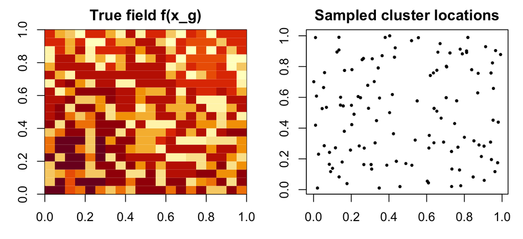

```r
# grid is expand.grid(s1, s2) with s1 varying fastest, so f_true already fills a
# (n_side x n_side) matrix column-major with rows = s1, columns = s2.
u1 <- sort(unique(grid$s1)); u2 <- sort(unique(grid$s2))
op <- par(mfrow = c(1, 2), mar = c(3, 3, 2, 1))
image(u1, u2, matrix(grid$f_true, nrow = length(u1)),
      main = "True field f(x_g)", xlab = "s1", ylab = "s2")
plot(obs$s1, obs$s2, pch = 19, cex = 0.4, col = "#00000066",
     main = "Sampled cluster locations", xlab = "s1", ylab = "s2")
```

```r
par(op)
```

## 3.1 Fit the four methods

```r
res_scenario <- run_scenario(
  omega = 0.5, surface = "tree", seed = 1,
  n_side = 20L, n_clusters = 120L,
  bartsimp_args = list(ntree = 40L, ndpost = 150L, nwarmup = 150L, seed = 1L),
  bart_args     = list(ntree = 40L, ndpost = 1000L, nskip = 1000L),
  verbose = FALSE
)
```

```r
knitr::kable(res_scenario[, c("method", "RMSE", "AIL", "ACR", "AIS")],
             digits = 3, row.names = FALSE,
             caption = "One replicate, omega = 0.5, tree surface.")
```

One replicate, omega = 0.5, tree surface.

| method | RMSE | AIL | ACR | AIS |
| --- | --- | --- | --- | --- |
| BARTSIMP | 0.293 | 0.992 | 0.925 | 1.629 |
| BART | 0.385 | 1.106 | 0.860 | 2.156 |
| SPDE | 0.555 | 1.821 | 0.902 | 2.613 |
| SPDE0 | 0.989 | 3.087 | 0.902 | 3.992 |

You should see the qualitative pattern from the paper: **BARTSIMP** attains the lowest RMSE and AIS because it captures *both* the covariate surface (via BART) and the residual spatial structure (via the Matérn field). BART alone recovers the covariate signal but under-covers (no spatial field); SPDE0 (spatial only) has the widest intervals and worst RMSE on a covariate-driven surface.

# 4 A small multi-scenario sweep

`run_section5()` loops over $\omega$ values, surfaces, and replicate seeds. Here is a deliberately small sweep; raise `reps`, `n_side`, and the MCMC sizes toward the paper settings as your compute budget allows.

```r
results <- run_section5(
  omegas = c(1, 0.5, 0), surfaces = "tree", reps = 1:3,
  n_side = 25L, n_clusters = 150L,
  bartsimp_args = list(ntree = 40L, ndpost = 200L, nwarmup = 200L),
  bart_args     = list(ntree = 40L, ndpost = 1000L, nskip = 1000L)
)
summarize_section5(results)   # scenario means, paper-table layout
```

The command-line driver does the same and writes CSVs to `reproduction/results/`:

```bash
Rscript reproduction/run_section5.R            # quick demo config
Rscript reproduction/run_section5.R --paper    # full paper-scale sweep
```

# 5 The fast spatial predictor (Woodbury)

Stage 2 of BARTSIMP — recovering the residual Matérn field for each posterior draw — was the runtime bottleneck in the original code: it refit an INLA/SPDE model *per draw*. With the Matérn hyperparameters held fixed at each draw’s $(\kappa, \sigma_m)$, that fit is exactly the posterior mean of a Gaussian Markov random field, which is available in closed form,

$$m_u = Q_u^{-1} A^\top \Omega\, r,
\qquad
Q_u = A^\top \Omega A + Q_\psi(\kappa, \sigma_m),$$

computed with a single sparse Cholesky. `BARTSIMP::bartsimp_predict()` exposes this as `method = "woodbury"`, which `fit_bartsimp()` uses by default here; `method = "inla"` restores the original per-draw INLA fit. The two are numerically equivalent — only the cost differs.

The chunk below isolates the predictor: it builds a mesh and a set of synthetic per-draw tree predictions, then runs both methods on identical inputs.

```r
set.seed(7)
n_tr <- 150L; ndraw <- 10L
s_tr <- data.frame(s1 = runif(n_tr), s2 = runif(n_tr))
s_te <- expand.grid(s1 = seq(0.02, 0.98, length.out = 18),
                    s2 = seq(0.02, 0.98, length.out = 18))
s_te <- data.frame(s1 = s_te$s1, s2 = s_te$s2)
mesh <- INLA::inla.mesh.2d(loc = as.matrix(s_tr),
                           max.edge = c(0.1, 0.4), cutoff = 0.02)

y_tr  <- rnorm(n_tr)
td_tr <- matrix(rnorm(ndraw * n_tr),       nrow = ndraw)
td_te <- matrix(rnorm(ndraw * nrow(s_te)), nrow = ndraw)
kap   <- runif(ndraw, 1.5, 3.5)
sgm   <- runif(ndraw, 0.4, 0.9)
sob   <- runif(ndraw, 0.8, 1.2)

pred_args <- list(y_train = y_tr, tree_draws_train = td_tr,
                  tree_draws_test = td_te, s_train = s_tr, s_test = s_te,
                  kappas = kap, sigmams = sgm, sigma_obs = sob, mesh = mesh)

t_inla <- system.time(
  p_inla <- do.call(BARTSIMP::bartsimp_predict,
                    c(pred_args, method = "inla")))[["elapsed"]]
t_wb <- system.time(
  p_wb <- do.call(BARTSIMP::bartsimp_predict,
                  c(pred_args, method = "woodbury")))[["elapsed"]]

round(c(
  max_abs_diff  = max(abs(p_inla$spatial_mean_test - p_wb$spatial_mean_test)),
  correlation   = cor(c(p_inla$spatial_mean_test), c(p_wb$spatial_mean_test)),
  inla_seconds  = t_inla,
  woodbury_secs = t_wb,
  speedup       = t_inla / t_wb), 4)
```

```
#>  max_abs_diff   correlation  inla_seconds woodbury_secs       speedup
#>        0.0000        1.0000       13.2360        0.0360      367.6667
```

The two spatial means agree to floating-point tolerance while the Woodbury path is far cheaper, and the gap widens with `ndpost`, the mesh size, and the number of prediction points. For the paper-scale sweep this turns Stage-2 prediction from a dominant cost into a negligible one.

# 6 Reproducing the paper-scale results

To match the paper exactly, use:

- `n_side = 50` ($|G| = 2500$), `n_clusters = 250`, `obs_range = 5:10`, `sigma2_e = 1`, Matérn `kappa = 2.5`, `nu = 1`, `sigma2_m = 0.5`.
- All five $\omega \in \{1, 0.8, 0.5, 0.2, 0\}$ and all three surfaces.
- BARTSIMP `ndpost = 1000`, `nwarmup = 1000`; BART `ndpost = nskip = 2000`.
- At least 20 replicate seeds per scenario, averaged with `summarize_section5()`.

**Runtime.** Stage-2 prediction now uses the Woodbury predictor by default (see the previous section), so it is cheap. The remaining cost is the C++ sampler (Stage 1), which still calls INLA once per MCMC iteration for the marginal likelihood and therefore dominates a paper-scale run: a full sweep is a multi-hour (to overnight) job.

**Further speedups.** The marginal likelihood evaluated inside the sampler has the same closed-form Gaussian (Woodbury / sparse-Cholesky) structure and can likewise be computed without INLA. That sampler-side optimization is tracked separately in the developer notes; the `method = "woodbury"` predictor above is the part that is already wired into the package and the reproduction fitter.